# gothaam_bl_ana

```python
## uncomment following line to make an html
!jupyter nbconvert --to html gothaam_bl_ana.ipynb
```

```
[NbConvertApp] Converting notebook gothaam_bl_ana.ipynb to html
[NbConvertApp] WARNING | Alternative text is missing on 21 image(s).
[NbConvertApp] Writing 5499432 bytes to gothaam_bl_ana.html
```

```python
import importlib
import gothaam_utils
import math
import numpy as np
import netCDF4
import pandas as pd
import numpy as np
import seaborn as sns
import matplotlib.pyplot as plt
from matplotlib.colors import LogNorm, Normalize, ListedColormap
from metpy.plots import SkewT
from metpy.units import pandas_dataframe_to_unit_arrays, units
from datetime import datetime, timedelta
from IPython.display import display
from bokeh.io import push_notebook, show, output_notebook
from bokeh.layouts import row
from bokeh.layouts import gridplot
from bokeh.plotting import figure, show
from bokeh.models import Title, CustomJS, Select, TextInput, Button, LinearAxis, Range1d
from bokeh.models.formatters import DatetimeTickFormatter
from bokeh.models.tickers import DatetimeTicker
from bokeh.palettes import Category10
import warnings
import itertools
import holoviews as hv
from holoviews import dim, opts
import hvplot.pandas
import copy
hv.extension('bokeh', 'matplotlib')
warnings.filterwarnings('ignore')
output_notebook()
%matplotlib inline
```

Loading BokehJS ...

# Boundary Layer Diagnosis

An attempt was only made to diagnose whether or not the C130 was flying in a **convective** boundary layer. A CBL:

- is forced by surface heating
- is turbulent
- is ~well-mixed vertically (~constant potential temperature, water vapor mixing ratio)
- has horizontal gradients forced by regional differences in surface heating, Bowen ratio, etc

The key variable used to diagnose whether or not the C130 was in a CBL was turbulence, quantified by the 2-second standard deviation of vertical wind velocity in the 25 Hz data. Potential temperature, water vapor mixing ratio, their vertical gradients where possible, as well as ERA5 skin temperatures interpolated to the aircraft track were used to help in this diagnosis. **Skin temperatures, particularly at night over the ocean (i.e. SSTs) were used to diagnose CBL periods at night.**

## Caveats

- Stable boundary layers are shallow BLs where the surface cools the lowest levesl of the atmosphere. The classical SBL is over land at night, where radiation to space cools a land surface layer quickly. Surface roughness forces some turbulence when a flow exists, forcing some turbulence that is mitigated by strong low-level stability.
  - Sometimes the ocean was cooler than the overlying airmass, leading to apparent SBLs during the day over the ocean. **These periods are not flagged as in the CBL**
- Occasionally, it appeared the C130 was flying within a CBL-top inversion. While technically it was rapidly entering and exiting the CBL due to penetrative eddies and plumes, these periods were typically flagged as CBL.

```python
# Open all netcdf flight files
importlib.reload(gothaam_utils)
data_dir = '/Users/ckruse/qaqc/GOTHAAM/data/v9'
nc_dict_25hz = gothaam_utils.open_nc(data_dir, freq='25Hz')
```

```
Found 0 proficiency, 1 ferry, 2 test, and 21 research flights
Opening all 25Hz flight NetCDF Files
Processing Date & Time: 2026-02-26T02:17:23 +0000
```

```python
# # Fire-up a dashboard used to easily find start and end times for CBL periods
# importlib.reload(gothaam_utils)

# flight = 'rf05'
# df_25hz = gothaam_utils.read_nc(nc_dict_25hz[flight], freq='25Hz')
# era5_file = gothaam_utils.download_era5_for_flight(df_25hz, output_file=f"era5_{flight}.nc")
# df_25hz = gothaam_utils.add_era5_to_flight_data(df_25hz, era5_file=era5_file)

# gothaam_utils.plot_interactive_profile_dashboard(
#     df_25hz,
#     title=f"{flight} Dashboard (with ERA5)",
#     window_n=50
# )
```

```python
# all the start and end times found using the dashboard in the previous cell for all GOTHAAM RFs
bl_periods_by_flight = {}
bl_periods_by_flight['rf01'] = [
    ['12:52:24', '12:54:02'], # Highlight 1
    ['13:27:34', '13:48:40'], # Highlight 2
    ['14:09:23', '14:38:12'], # Highlight 3
    ['15:06:54', '17:24:02'], # Highlight 4
    ['17:53:50', '17:55:51'], # Highlight 5
]
bl_periods_by_flight['rf02'] = [
    ['14:43:06', '14:45:24'], # Highlight 1
    ['15:22:00', '15:38:12'], # Highlight 2
    ['15:56:42', '17:35:11'], # Highlight 3
    ['17:38:43', '17:49:46'], # Highlight 4
    ['17:53:46', '18:13:46'], # Highlight 5
    ['18:18:04', '18:22:04'], # Highlight 6
    ['18:41:03', '19:09:57'], # Highlight 7
    ['19:31:37', '19:36:37'], # Highlight 8
]
bl_periods_by_flight['rf03'] = [
    ['14:52:04', '14:53:54'], # Highlight 1
    ['15:16:04', '15:33:56'], # Highlight 2
    ['15:52:19', '16:28:11'], # Highlight 3
    ['17:05:01', '17:57:38'], # Highlight 4
    ['18:41:44', '18:54:31'], # Highlight 5
    ['18:59:56', '19:02:38'], # Highlight 6
]
bl_periods_by_flight['rf04'] = [
    ['13:59:09', '14:00:55'], # Highlight 1
    ['15:25:27', '16:53:32'], # Highlight 2
    ['16:55:15', '16:59:53'], # Highlight 3
    ['17:11:11', '17:11:47'], # Highlight 4
    ['17:13:22', '17:17:18'], # Highlight 5
    ['17:23:37', '17:29:59'], # Highlight 6
    ['17:39:25', '17:41:21'], # Highlight 7
    ['19:00:43', '19:24:09'], # Highlight 8
]
# For rf05, there were some weakly-turbulent periods flown at low-levels that at first glance looked like CBL periods.
# However, ascents and descents prior to these periods suggest a strong theta gradient to this level, suggestive of
# daytime stable BLs. The ERA5 SSTs are consistent with this! So, these periods were not included in these CBL periods.
bl_periods_by_flight['rf05'] = [
    ['16:54:53', '16:59:07'], # Highlight 1
    ['19:07:21', '19:16:37'], # Highlight 2
    ['19:58:14', '20:10:21'], # Highlight 3
    ['22:15:03', '22:16:26'], # Highlight 4
]
bl_periods_by_flight['rf06'] = [
    ['17:02:58', '17:04:24'], # Highlight 1
    ['17:58:05', '18:38:53'], # Highlight 2
    ['18:43:06', '18:48:26'], # Highlight 3
    ['19:09:33', '19:49:23'], # Highlight 4
    ['20:18:51', '20:24:13'], # Highlight 5
    ['22:50:58', '22:52:56'], # Highlight 6
]
bl_periods_by_flight['rf07'] = [
    ['21:05:16', '21:07:44'], # Highlight 1
    ['21:36:37', '22:03:11'], # Highlight 2
]
bl_periods_by_flight['rf08'] = [
    ['21:28:53', '21:30:04'], # Highlight 1
    ['22:27:18', '22:59:06'], # Highlight 2
    ['00:07:20', '00:09:42'], # Highlight 3
    ['00:14:13', '00:20:57'], # Highlight 4
]
bl_periods_by_flight['rf09'] = [
    ['21:20:46', '21:22:29'], # Highlight 1
    ['21:53:50', '22:00:07'], # Highlight 2
    ['22:25:37', '23:04:10'], # Highlight 3
    ['00:18:47', '00:31:23'], # Highlight 4
    ['02:17:58', '02:26:06'], # Highlight 5
    ['02:29:20', '02:31:56'], # Highlight 6
]
bl_periods_by_flight['rf10'] = [
    ['21:21:31', '21:22:50'], # Highlight 1
    ['22:03:49', '22:15:51'], # Highlight 2
    ['23:02:19', '23:05:12'], # Highlight 3
    ['00:05:36', '00:08:20'], # Highlight 4
    ['00:10:56', '00:15:45'], # Highlight 5
    ['02:04:01', '02:21:45'], # Highlight 6
]
bl_periods_by_flight['rf11'] = [
    ['17:52:02', '17:56:22'], # Highlight 1
    ['18:17:02', '18:23:11'], # Highlight 2
    ['18:30:15', '20:00:42'], # Highlight 3
    ['20:03:06', '20:14:56'], # Highlight 4
    ['20:18:07', '20:59:49'], # Highlight 5
    ['21:34:29', '21:56:37'], # Highlight 6
    ['22:11:15', '22:27:13'], # Highlight 7
    ['22:44:57', '23:21:28'], # Highlight 8
    ['00:20:27', '00:22:04'], # Highlight 9
]
bl_periods_by_flight['rf12'] = [
    ['00:57:47', '00:58:49'], # Highlight 1
    ['01:29:15', '01:33:34'], # Highlight 2
    ['05:27:19', '05:30:32'], # Highlight 3
    ['05:40:09', '05:43:16'], # Highlight 4
    ['05:46:25', '05:50:17'], # Highlight 5
]
bl_periods_by_flight['rf13'] = [
    ['01:09:50', '01:11:19'], # Highlight 1
    ['01:43:02', '01:52:15'], # Highlight 2
    ['02:02:06', '02:10:08'], # Highlight 3
    ['04:47:04', '04:48:19'], # Highlight 4
    ['06:02:51', '06:05:34'], # Highlight 5
    ['06:22:50', '06:24:47'], # Highlight 6
]
bl_periods_by_flight['rf14'] = [
    ['04:48:12', '04:52:07'], # Highlight 1
    ['04:58:20', '04:59:40'], # Highlight 2
    ['06:46:06', '06:49:46'], # Highlight 3
    ['07:21:28', '07:22:41'], # Highlight 4
    ['07:30:29', '07:31:47'], # Highlight 5
]
bl_periods_by_flight['rf15'] = [
    ['02:31:59', '02:33:17'], # Highlight 1
    ['05:17:42', '05:24:25'], # Highlight 2
    ['06:18:24', '06:20:28'], # Highlight 3
    ['07:11:43', '07:15:13'], # Highlight 4
    ['08:21:25', '08:28:30'], # Highlight 5
]
bl_periods_by_flight['rf16'] = [
    ['04:15:03', '04:41:44'], # Highlight 1
    ['06:20:53', '06:33:55'], # Highlight 2
    ['06:46:23', '07:01:28'], # Highlight 3
    ['07:04:46', '07:12:07'], # Highlight 4
    ['07:16:05', '07:22:28'], # Highlight 5
    ['08:38:02', '08:51:06'], # Highlight 6
    ['09:04:10', '09:05:09'], # Highlight 7
    ['09:16:07', '09:17:12'], # Highlight 8
]
bl_periods_by_flight['rf17'] = [
    ['06:19:35', '06:21:11'], # Highlight 1
    ['06:49:22', '06:50:28'], # Highlight 2
    ['08:10:05', '08:12:00'], # Highlight 3
    ['08:24:19', '08:30:14'], # Highlight 4
    ['08:37:41', '08:43:04'], # Highlight 5
    ['08:52:38', '08:57:19'], # Highlight 6
    ['09:07:34', '09:10:24'], # Highlight 7
    ['10:22:28', '10:29:45'], # Highlight 8
    ['10:34:50', '10:39:00'], # Highlight 9
    ['11:10:42', '11:15:02'], # Highlight 10
    ['11:28:10', '11:29:29'], # Highlight 11
    ['11:38:20', '11:40:55'], # Highlight 12
    ['11:47:37', '11:49:56'], # Highlight 13
    ['11:55:06', '11:58:08'], # Highlight 14
    ['12:05:52', '12:08:36'], # Highlight 15
    ['12:10:38', '12:12:18'], # Highlight 16
]
bl_periods_by_flight['rf18'] = [
    ['09:27:19', '09:30:38'], # Highlight 1
    ['11:56:19', '11:57:23'], # Highlight 2
    ['12:11:29', '12:16:14'], # Highlight 3
    ['12:24:16', '12:31:15'], # Highlight 4
    ['13:02:05', '13:03:43'], # Highlight 5
]
bl_periods_by_flight['rf19'] = [
    ['07:56:35', '08:00:17'], # Highlight 1
    ['08:55:29', '08:56:00'], # Highlight 2
    ['09:28:53', '09:34:31'], # Highlight 3
    ['10:17:54', '10:21:02'], # Highlight 4
    ['11:59:56', '12:01:47'], # Highlight 5
    ['12:29:17', '12:34:02'], # Highlight 6
    ['12:55:53', '13:00:43'], # Highlight 7
    ['13:14:28', '13:17:30'], # Highlight 8
    ['13:28:05', '13:31:07'], # Highlight 9
]
bl_periods_by_flight['rf20'] = [
    ['09:02:14', '09:06:32'], # Highlight 1
    ['09:55:40', '09:56:38'], # Highlight 2
    ['10:32:58', '10:35:46'], # Highlight 3
    ['10:45:54', '10:48:10'], # Highlight 4
    ['11:33:57', '11:35:05'], # Highlight 5
    ['12:07:19', '12:09:14'], # Highlight 6
    ['12:18:56', '12:20:58'], # Highlight 7
    ['12:28:29', '12:32:48'], # Highlight 8
    ['12:36:36', '12:37:26'], # Highlight 9
    ['12:38:44', '12:41:20'], # Highlight 10
    ['13:03:31', '13:05:34'], # Highlight 11
    ['13:15:23', '13:16:57'], # Highlight 12
    ['13:23:23', '13:30:25'], # Highlight 13
    ['13:35:53', '13:38:31'], # Highlight 14
    ['13:41:43', '13:45:28'], # Highlight 15
    ['13:51:14', '14:03:10'], # Highlight 16
]
bl_periods_by_flight['rf21'] = [
    ['09:04:33', '09:04:38'], # Highlight 1
    ['10:46:54', '10:52:39'], # Highlight 2
    ['11:00:11', '11:01:24'], # Highlight 3
    ['11:09:30', '11:10:15'], # Highlight 4
    ['11:19:10', '11:19:18'], # Highlight 5
    ['11:25:02', '11:29:51'], # Highlight 6
    ['11:35:34', '11:39:20'], # Highlight 7
    ['11:45:45', '11:49:42'], # Highlight 8
    ['11:55:33', '11:57:20'], # Highlight 9
    ['12:35:05', '12:36:02'], # Highlight 10
    ['13:20:33', '13:21:49'], # Highlight 11
    ['13:44:31', '13:48:49'], # Highlight 12
    ['14:05:50', '14:07:39'], # Highlight 13
    ['14:08:43', '14:11:36'], # Highlight 14
    ['14:29:49', '14:31:35'], # Highlight 15
    ['14:35:35', '14:37:45'], # Highlight 16
    ['14:39:00', '14:42:04'], # Highlight 17
    ['14:46:43', '14:50:07'], # Highlight 18
    ['14:54:54', '14:56:47'], # Highlight 19
    ['15:00:38', '15:16:25'], # Highlight 20
]
```

```
Found existing ERA5 file at era5_rf01.nc. Skipping download.
Interpolating ERA5 data to 1Hz flight track (Fast Mode)...
Upsampling ERA5 data back to high-rate flight track...
Calculating Skin Potential Temperature...
```

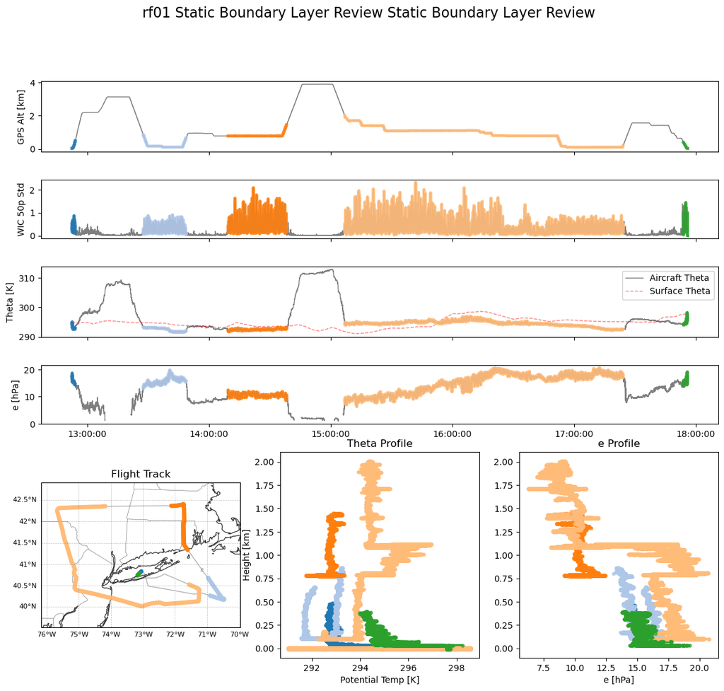

```
Found existing ERA5 file at era5_rf02.nc. Skipping download.
Interpolating ERA5 data to 1Hz flight track (Fast Mode)...
Upsampling ERA5 data back to high-rate flight track...
Calculating Skin Potential Temperature...
```

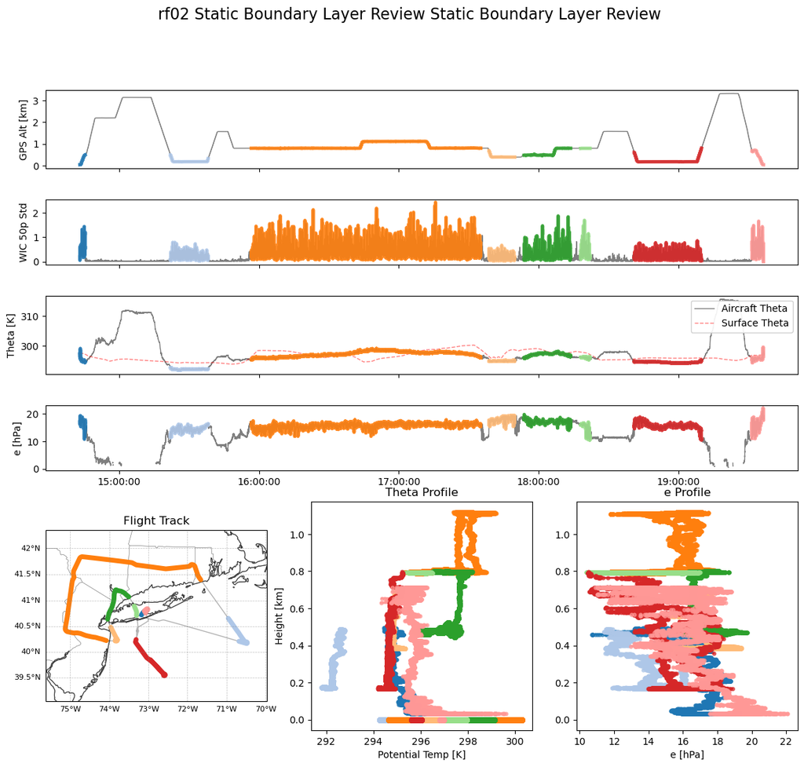

```
Found existing ERA5 file at era5_rf03.nc. Skipping download.
Interpolating ERA5 data to 1Hz flight track (Fast Mode)...
Upsampling ERA5 data back to high-rate flight track...
Calculating Skin Potential Temperature...
```

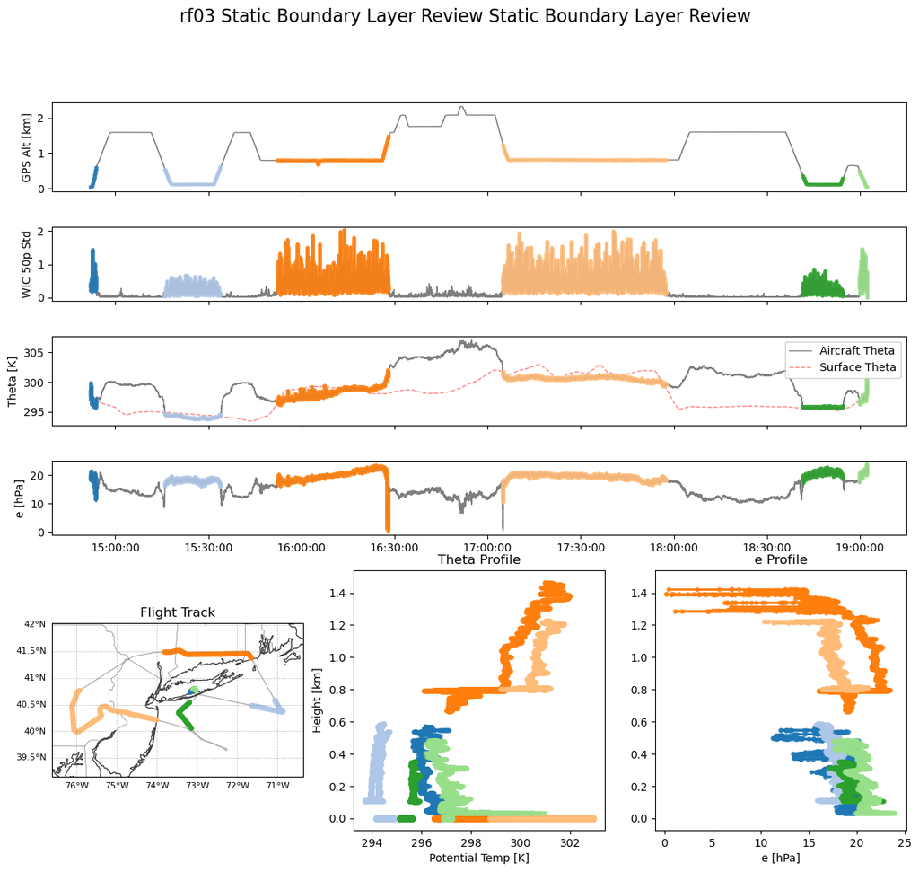

```
Found existing ERA5 file at era5_rf04.nc. Skipping download.
Interpolating ERA5 data to 1Hz flight track (Fast Mode)...
Upsampling ERA5 data back to high-rate flight track...
Calculating Skin Potential Temperature...
```

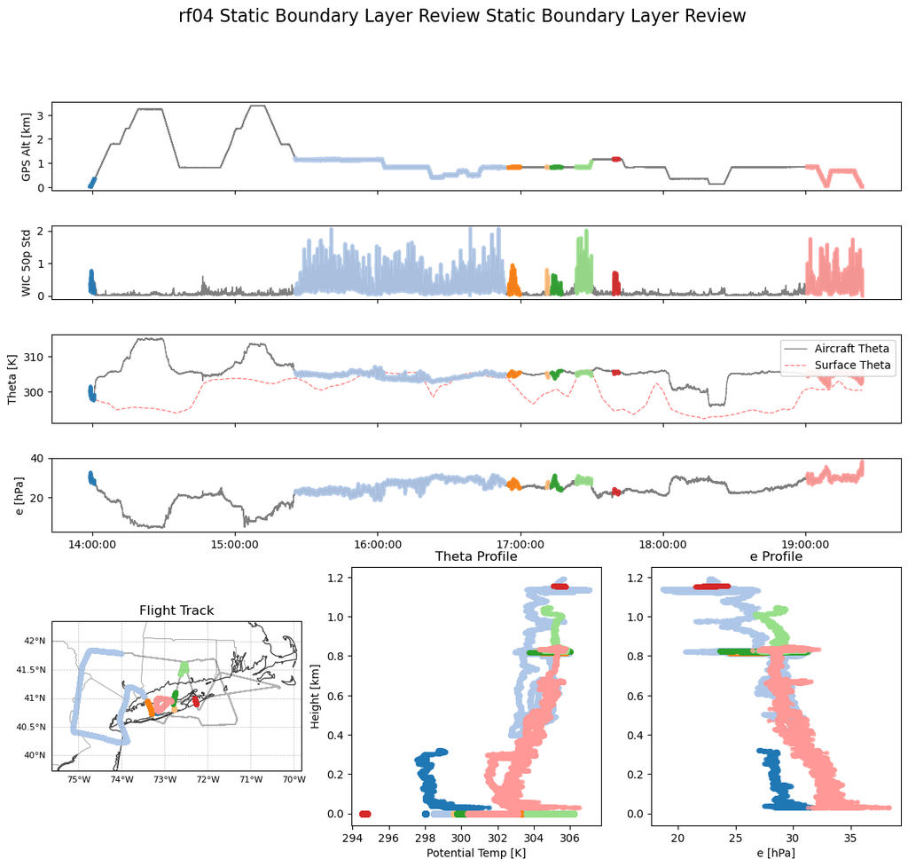

```
Found existing ERA5 file at era5_rf05.nc. Skipping download.
Interpolating ERA5 data to 1Hz flight track (Fast Mode)...
Upsampling ERA5 data back to high-rate flight track...
Calculating Skin Potential Temperature...
```

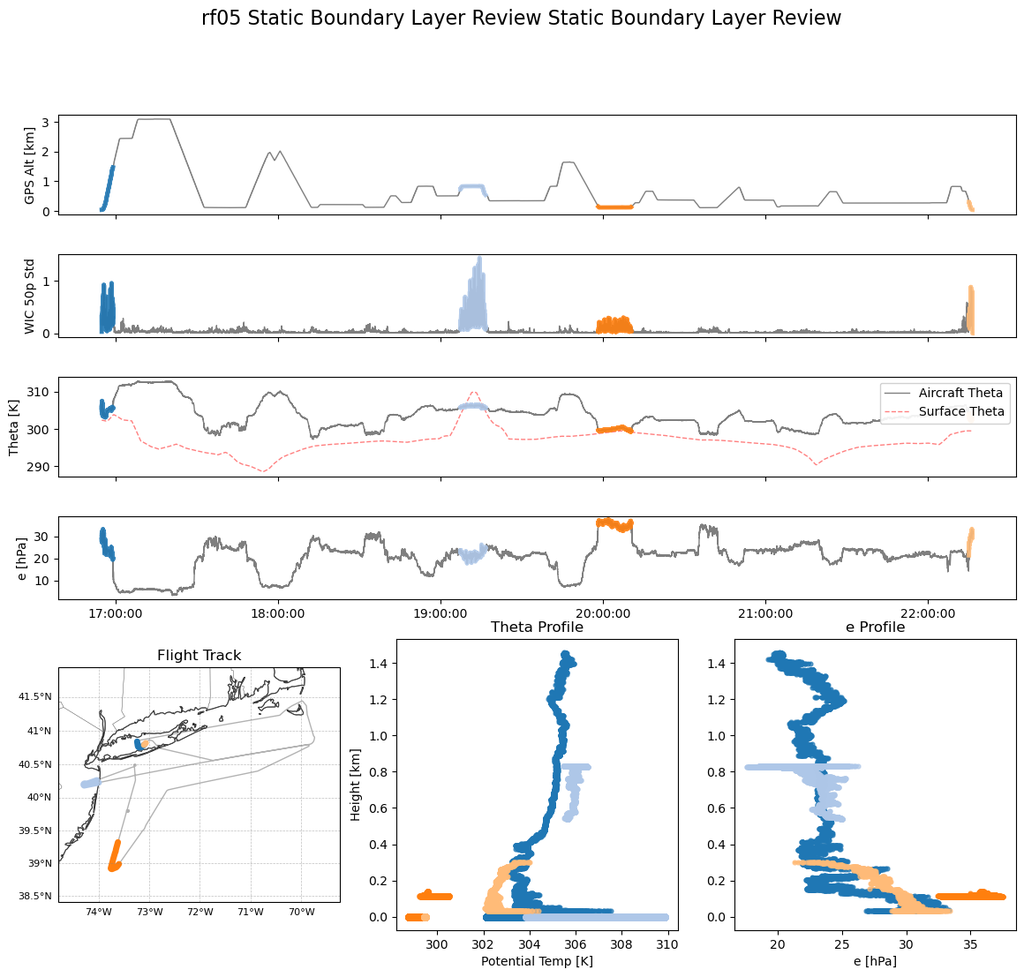

```
Found existing ERA5 file at era5_rf06.nc. Skipping download.
Interpolating ERA5 data to 1Hz flight track (Fast Mode)...
Upsampling ERA5 data back to high-rate flight track...
Calculating Skin Potential Temperature...
```

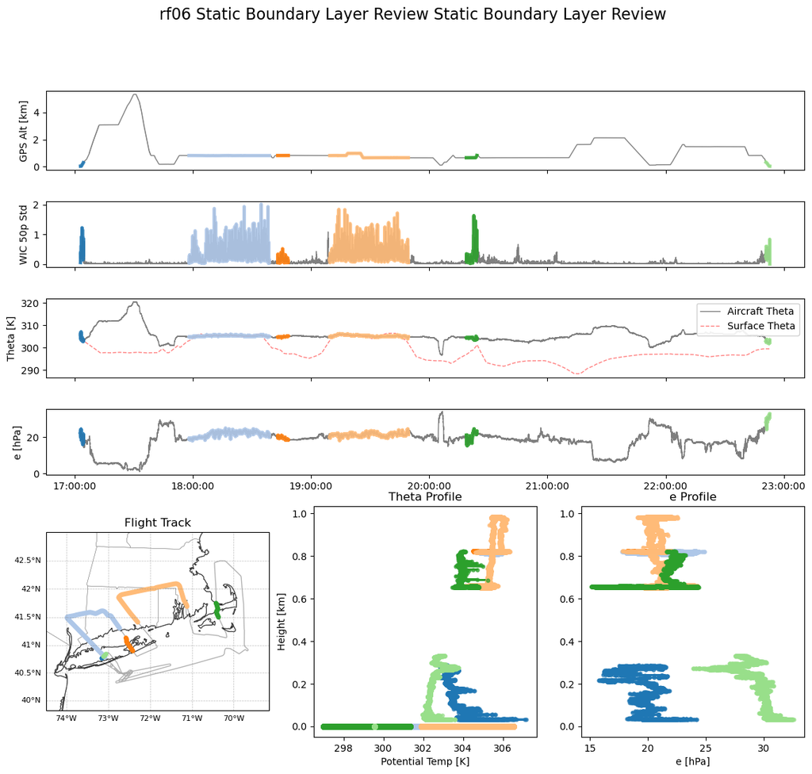

```
Found existing ERA5 file at era5_rf07.nc. Skipping download.
Interpolating ERA5 data to 1Hz flight track (Fast Mode)...
Upsampling ERA5 data back to high-rate flight track...
Calculating Skin Potential Temperature...
```

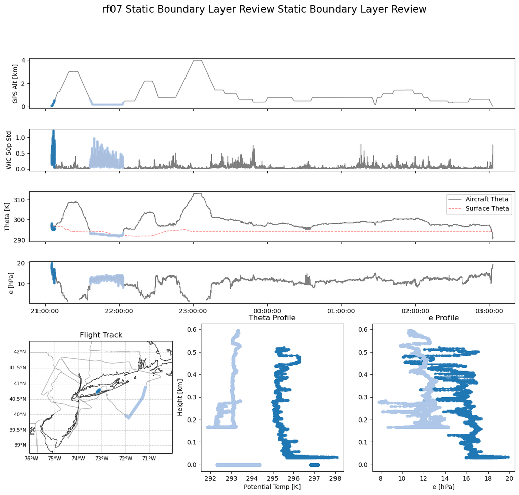

```
Found existing ERA5 file at era5_rf08.nc. Skipping download.
Interpolating ERA5 data to 1Hz flight track (Fast Mode)...
Upsampling ERA5 data back to high-rate flight track...
Calculating Skin Potential Temperature...
```

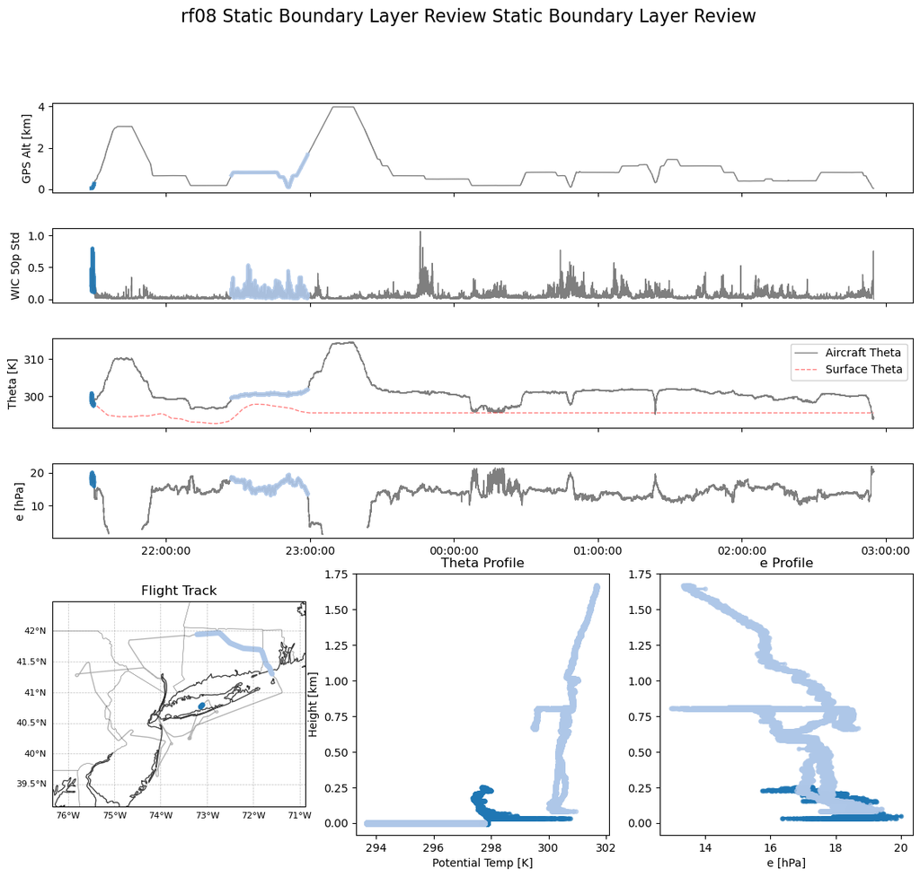

```
Found existing ERA5 file at era5_rf09.nc. Skipping download.
Interpolating ERA5 data to 1Hz flight track (Fast Mode)...
Upsampling ERA5 data back to high-rate flight track...
Calculating Skin Potential Temperature...
```

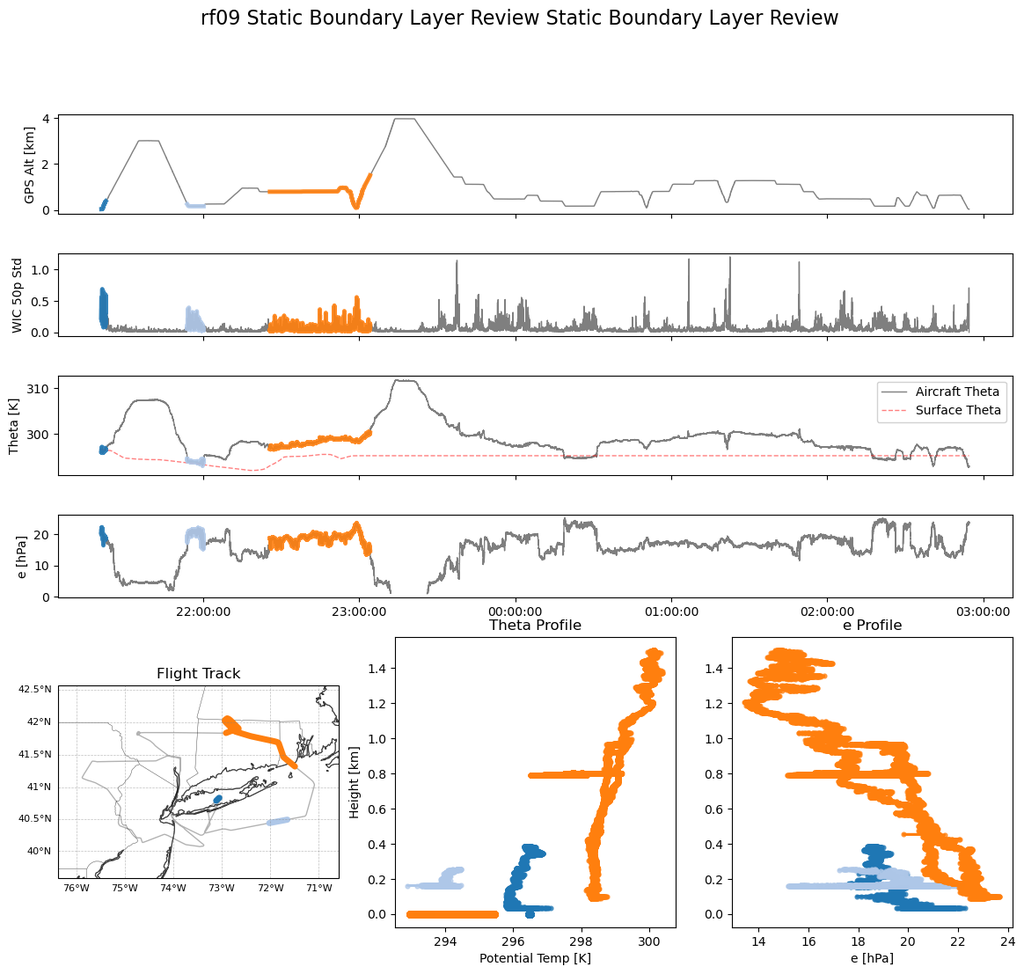

```
Found existing ERA5 file at era5_rf10.nc. Skipping download.
Interpolating ERA5 data to 1Hz flight track (Fast Mode)...
Upsampling ERA5 data back to high-rate flight track...
Calculating Skin Potential Temperature...
```

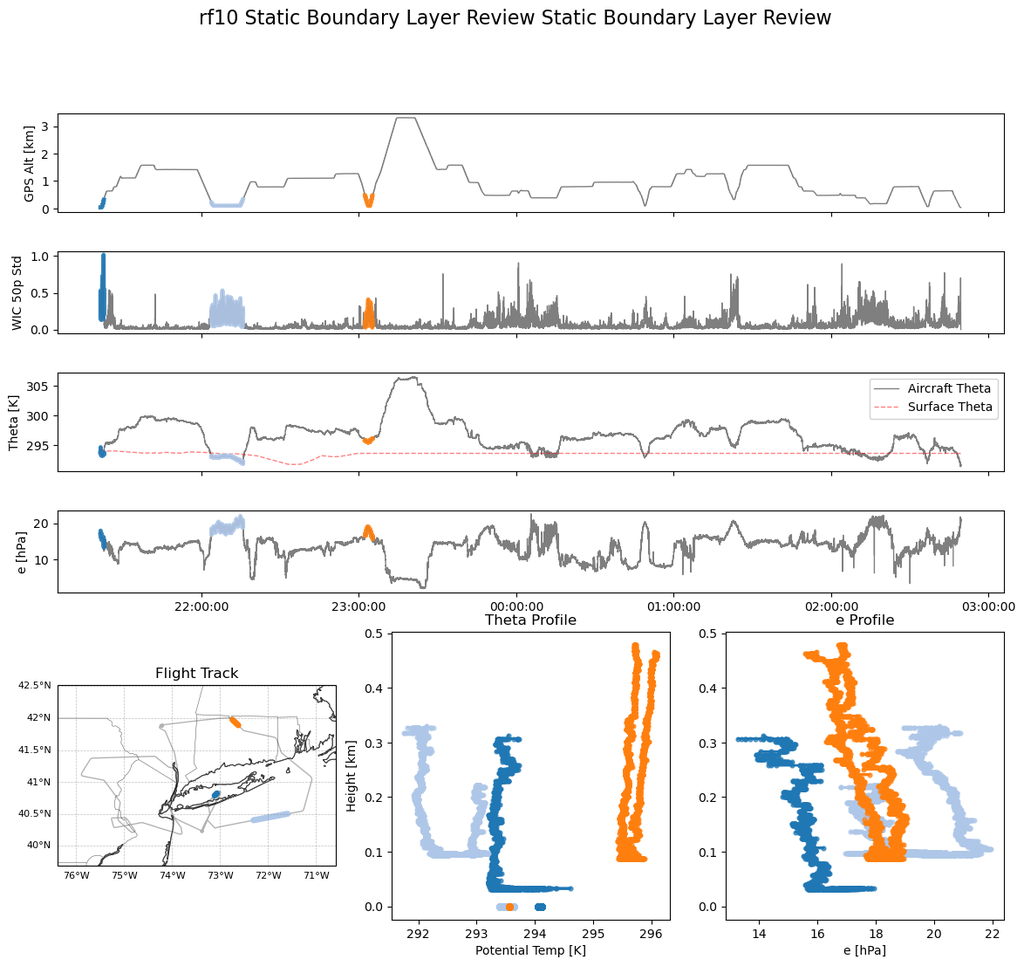

```
Found existing ERA5 file at era5_rf11.nc. Skipping download.
Interpolating ERA5 data to 1Hz flight track (Fast Mode)...
Upsampling ERA5 data back to high-rate flight track...
Calculating Skin Potential Temperature...
```

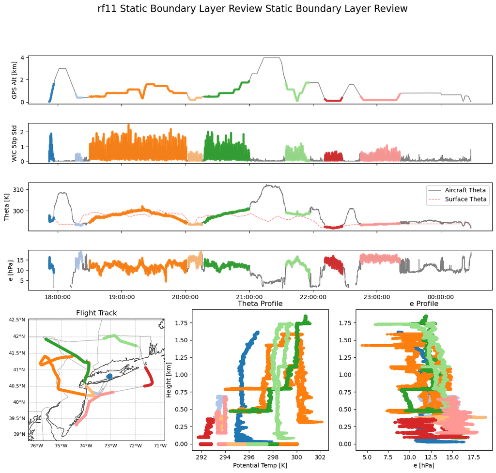

```
Found existing ERA5 file at era5_rf12.nc. Skipping download.
Interpolating ERA5 data to 1Hz flight track (Fast Mode)...
Upsampling ERA5 data back to high-rate flight track...
Calculating Skin Potential Temperature...
```

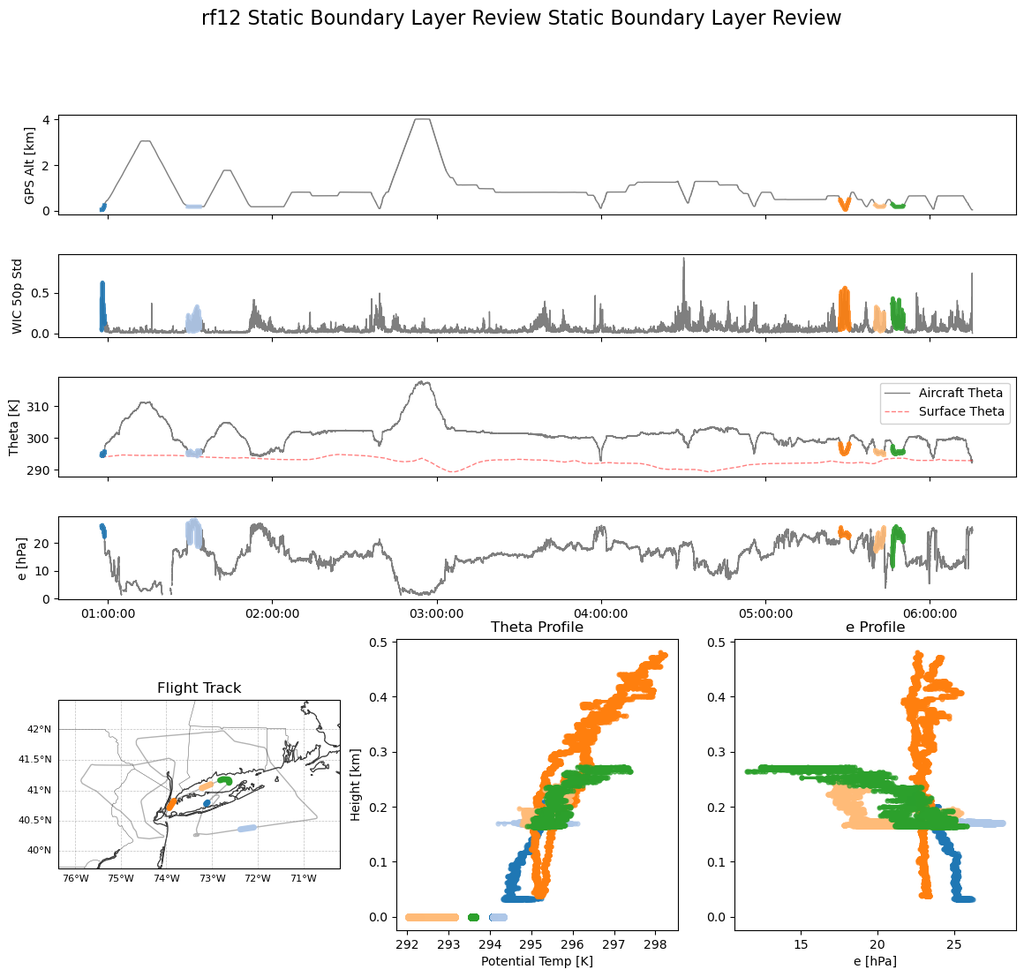

```
Found existing ERA5 file at era5_rf13.nc. Skipping download.
Interpolating ERA5 data to 1Hz flight track (Fast Mode)...
Upsampling ERA5 data back to high-rate flight track...
Calculating Skin Potential Temperature...
```

[9 more figures not shown]

```python
# Plot up time series, maps, and profiles highlighting all the periods for all the flights
importlib.reload(gothaam_utils)

for flight in nc_dict_25hz.keys():
    if 'rf' not in flight:
        continue
    df_25hz = gothaam_utils.read_nc(nc_dict_25hz[flight], freq='25Hz')
    era5_file = gothaam_utils.download_era5_for_flight(df_25hz, output_file=f"era5_{flight}.nc")
    df_25hz = gothaam_utils.add_era5_to_flight_data(df_25hz, era5_file=era5_file)
    gothaam_utils.plot_static_profile_dashboard(
        df_25hz,
        bl_periods=bl_periods_by_flight[flight],
        title=f"{flight} Static Boundary Layer Review",
        window_n=50
    )
```